# Reproducible Research: Peer Assessment 1

Bartek Bielski

17 marca 2018

#### Introduction

This assignment is part of **Reproducible Research** course in Data Science specialization.

#### Data

This assignment makes use of data from a personal activity monitoring device. This device collects data at 5 minute intervals through out the day. The data consists of two months of data from an anonymous individual collected during the months of October and November, 2012 and include the number of steps taken in 5 minute intervals each day. Dataset can be downloaded from: [here](https://d396qusza40orc.cloudfront.net/repdata%2Fdata%2Factivity.zip) [52K]

#### Loading and preprocessing the data

```r
if(!file.exists("activity.csv")) {
    temp <- tempfile()
    download.file("http://d396qusza40orc.cloudfront.net/repdata%2Fdata%2Factivity.zip",temp)
    unzip(temp)
    unlink(temp)
    rm(temp)
}

ACdata <- read.csv("activity.csv")
```

#### What is mean total number of steps taken per day?

Sum steps by day, create Histogram, and calculate mean and median.

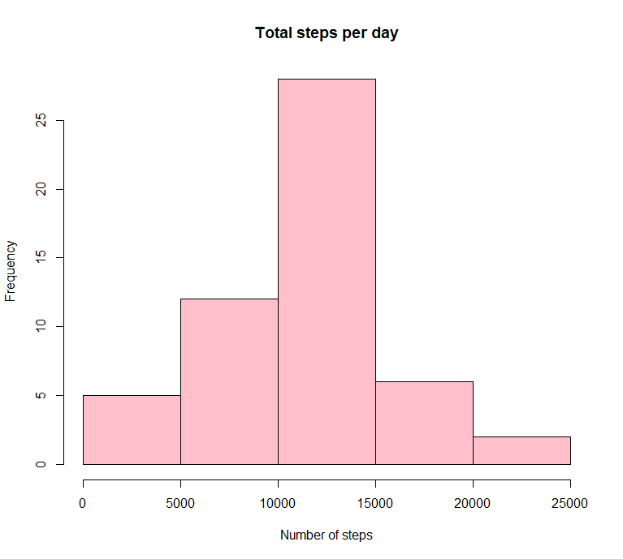

Histogram of number of steps per day

```r
spd <- aggregate(steps~date, ACdata, sum)
hist(spd$steps, main = "Total steps per day", col = "pink", xlab = "Number of steps")
```

Caluclating mean and median of steps per day

```r
rmean <- mean(spd$steps)
rmedian <- median(spd$steps)
```

Mean steps per day is: `10766.19` Median of steps per day is: `10765`

#### What is the average daily activity pattern?

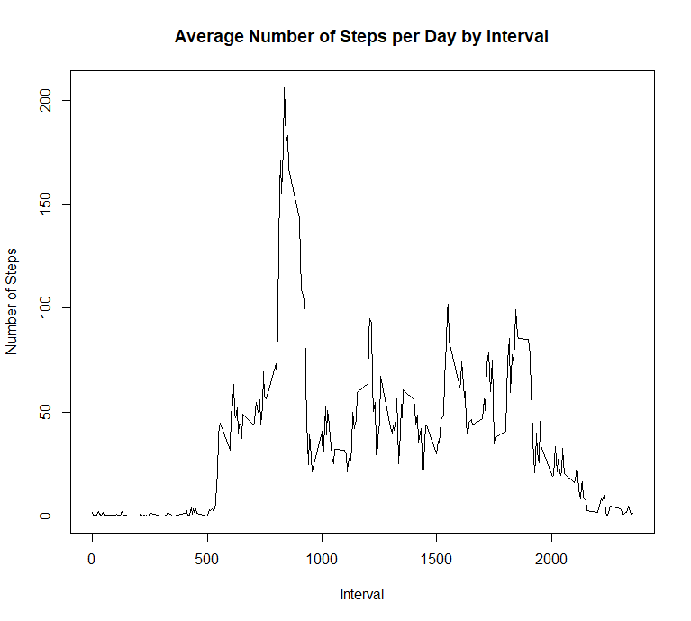

Average Number of Steps per Day by Interval

```r
spi <- aggregate(steps ~ interval, ACdata, mean)
plot(spi$interval, spi$steps, type="l", xlab="Interval", ylab="Number of Steps", main="Average Number of Steps per Day by Interval")
```

```r
maxi <- spi[which.max(spi$steps),1]
```

#### Imputing missing values

```r
missdatasum <- sum(!complete.cases(ACdata))
imputed_miss_data <- transform(ACdata, steps = ifelse(is.na(ACdata$steps), spi$steps[match(ACdata$interval, spi$interval)], ACdata$steps))
```

As for 2012-10-01 NA’s can be observed througout the day, this is first day of observation, so zeros were imputed to keep rising trend in dataset.

```r
imputed_miss_data[as.character(imputed_miss_data$date) == "2012-10-01", 1] <- 0
```

Now total steps per day were recalculated and histogram plotted

[figure not shown]

Total Steps per Day with NAs repalced

```r
spd_i <- aggregate(steps ~ date, imputed_miss_data, sum)
hist(spd_i$steps, main = "Total Steps Per Day", col="green", xlab="Number of Steps")

hist(spd$steps, main = "Total Steps Per Day", col="blue", xlab="Number of Steps", add=T)
legend("topright", c("Imputed", "Non-imputed"), col=c("green", "blue"), lwd=10)
```

New mean and new median ware calculated for transformed dataset:

```r
rmean_i <- mean(spd_i$steps)
rmedian_i <- median(spd_i$steps)
```

..so difference between imputed and non-imputed data could also be computed:

```r
mean_diff <- rmean_i - rmean
med_diff <- rmedian_i - rmedian
```

The total difference between imputed and non-imputed data was also calculated.

```r
total_diff <- sum(spd_i$steps) - sum(spd$steps)
```

###### Summary of computation

- new mean equals `10589.69`
- new median equals `10766.19`
- difference between mean for imputed and non-imputed data is `-176.49`
- difference between median for imputed and non-imputed data is `1.19`
- total number of steps in imputed data than in non-imputed data is higher by `75 363` steps

#### Are there differences in activity patterns between weekdays and weekends?

Code for labeling data:

```r
imputed_miss_data$dow <- ifelse(wday(imputed_miss_data$date, week_start = getOption("lubridate.week.start", 1)) %in% c(1,5), "Weekday", "Weekend")
```

Creating plot:

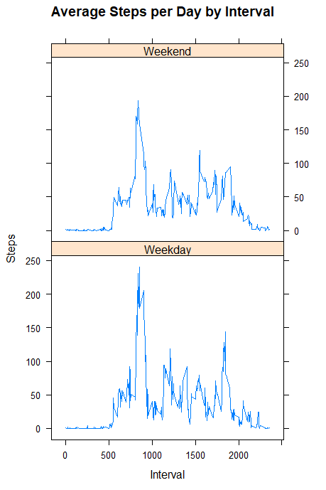

Activity pattern during the week and on weekends

```r
spi_i <- aggregate(steps ~ interval + dow, imputed_miss_data, mean)
xyplot(spi_i$steps ~ spi_i$interval|spi_i$dow, main="Average Steps per Day by Interval",xlab="Interval", ylab="Steps",layout=c(1,2), type="l")
```